# Analises2

## BAIXAR ARQUIVOS CANDIDATURAS

```python
import pathlib
import basedosdados as bd

# 1. Definir caminhos
BASE_DIR = pathlib.Path(r"C:\Users\Artur\TCC_UNIV")
DATA_DIR = BASE_DIR / "data"
DATA_DIR.mkdir(parents=True, exist_ok=True)

# 2. Consulta SQL para buscar candidaturas de SP (2012 a 2024)
query = """
SELECT
    ano AS ANO_ELEICAO,
    sigla_uf AS SG_UF,
    genero AS DS_GENERO,
    raca AS DS_COR_RACA,
    cargo AS DS_CARGO,
    resultado AS DS_SIT_TOT_TURNO
FROM `basedosdados.br_tse_eleicoes.candidatos`
WHERE sigla_uf = 'SP'
  AND ano IN (2012, 2016, 2020, 2024)
"""

print("Baixando dados reais do TSE via Base dos Dados...")

# O projeto 'billing_project_id' pode ser deixado com um nome de projeto do Google Cloud ou configurado no GCP
df_tse = bd.read_sql(query, billing_project_id="tcc-univesp-analise")

# 3. Salvar no diretório data
caminho_parquet = DATA_DIR / "tse_candidatos_sp_2012_2024.parquet"
df_tse.to_parquet(caminho_parquet, index=False)

print(f"✅ Arquivo real do TSE salvo com sucesso em: {caminho_parquet}")
```

### análises interseccionais

```
Total de registros carregados: 339,985

--- Distribuição Percentual por Ano (%) ---
INTERSECCIONAL  Feminino - Amarela  Feminino - Branca  Feminino - Indigena  \
ANO_ELEICAO
2016                          0.10              24.11                 0.04
2020                          0.10              24.02                 0.03
2024                          0.11              22.96                 0.05

INTERSECCIONAL  Feminino - Parda  Feminino - Preta  Masculino - Amarela  \
ANO_ELEICAO
2016                        5.37              2.37                 0.31
2020                        6.15              3.23                 0.25
2024                        7.51              3.59                 0.31

INTERSECCIONAL  Masculino - Branca  Masculino - Indigena  Masculino - Parda  \
ANO_ELEICAO
2016                         49.56                  0.05              12.97
2020                         45.90                  0.05              14.15
2024                         43.28                  0.06              15.86

INTERSECCIONAL  Masculino - Preta
ANO_ELEICAO
2016                         5.14
2020                         6.11
2024                         6.27
```

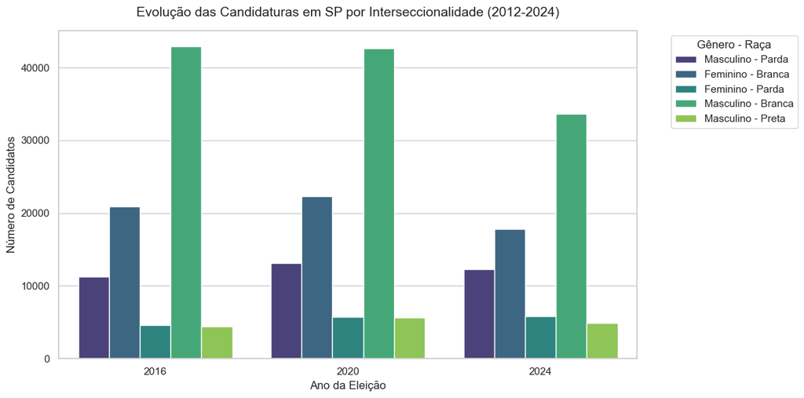

```python
import pathlib
import pandas as pd
import matplotlib.pyplot as plt
import seaborn as sns

# 1. Carregar os dados do arquivo Parquet
BASE_DIR = pathlib.Path(r"C:\Users\Artur\TCC_UNIV")
DATA_DIR = BASE_DIR / "data"
caminho_parquet = DATA_DIR / "tse_candidatos_sp_2012_2024.parquet"

df_tse = pd.read_parquet(caminho_parquet)
print(f"Total de registros carregados: {len(df_tse):,}")

# 2. Criar a variável Interseccional (Gênero + Raça)
df_tse["INTERSECCIONAL"] = df_tse["DS_GENERO"].str.title() + " - " + df_tse["DS_COR_RACA"].str.title()

# 3. Tabela de Frequência por Ano e Interseccionalidade
tabela_cruzada = pd.crosstab(
    df_tse["ANO_ELEICAO"],
    df_tse["INTERSECCIONAL"],
    normalize="index"
) * 100

print("\n--- Distribuição Percentual por Ano (%) ---")
print(tabela_cruzada.round(2))

# 4. Visualização Gráfica
plt.figure(figsize=(12, 6))
sns.set_theme(style="whitegrid")

# Filtrando as 5 principais combinações para evitar poluição no gráfico
top_grupos = df_tse["INTERSECCIONAL"].value_counts().head(5).index
df_filtered = df_tse[df_tse["INTERSECCIONAL"].isin(top_grupos)]

ax = sns.countplot(
    data=df_filtered,
    x="ANO_ELEICAO",
    hue="INTERSECCIONAL",
    palette="viridis"
)

plt.title("Evolução das Candidaturas em SP por Interseccionalidade (2012-2024)", fontsize=14, pad=15)
plt.xlabel("Ano da Eleição", fontsize=12)
plt.ylabel("Número de Candidatos", fontsize=12)
plt.legend(title="Gênero - Raça", bbox_to_anchor=(1.05, 1), loc='upper left')
plt.tight_layout()

plt.show()
```

### Script de Limpeza e Harmonização

```python
import pathlib
import pandas as pd

# 1. Carregar bases
BASE_DIR = pathlib.Path(r"C:\Users\Artur\TCC_UNIV")
DATA_DIR = BASE_DIR / "data"

df_tse = pd.read_parquet(DATA_DIR / "tse_candidatos_sp_2012_2024.parquet")

# 2. Dicionários de Padronização (TSE -> IBGE)
mapa_genero = {
    "MASCULINO": "MASCULINO",
    "FEMININO": "FEMININO"
}

mapa_raca = {
    "BRANCA": "BRANCA",
    "PRETA": "PRETA",
    "PARDA": "PARDA",
    "AMARELA": "AMARELA",
    "INDÍGENA": "INDIGENA",
    "INDIGENA": "INDIGENA"
}

# 3. Aplicação do Tratamento e Filtros
df_tse_limpo = df_tse.copy()

# Normalizar texto (remover espaços sobressalentes)
df_tse_limpo["DS_GENERO"] = df_tse_limpo["DS_GENERO"].astype(str).str.strip().str.upper()
df_tse_limpo["DS_COR_RACA"] = df_tse_limpo["DS_COR_RACA"].astype(str).str.strip().str.upper()

# Mapear variáveis padronizadas
df_tse_limpo["sexo_std"] = df_tse_limpo["DS_GENERO"].map(mapa_genero)
df_tse_limpo["cor_raca_std"] = df_tse_limpo["DS_COR_RACA"].map(mapa_raca)

# Descartar registros sem informação demográfica válida
df_tse_limpo = df_tse_limpo.dropna(subset=["sexo_std", "cor_raca_std"])

# 4. Exportar base pronta para a etapa de Análise
caminho_saida = DATA_DIR / "tse_candidatos_sp_limpo.parquet"
df_tse_limpo.to_parquet(caminho_saida, index=False)

print(f"✅ Processamento concluído!")
print(f"Registros brutos: {len(df_tse):,} | Registros válidos pós-limpeza: {len(df_tse_limpo):,}")
```

```
✅ Processamento concluído!
Registros brutos: 339,985 | Registros válidos pós-limpeza: 257,260
```

```
--- RAZÃO DE REPRESENTATIVIDADE (Candidatos / População IBGE) ---
Valores < 1.0 = Sub-representado | Valores > 1.0 = Sobre-representado
```

| ANO_ELEICAO interseccional | 2016 | 2020 | 2024 |
| --- | --- | --- | --- |
| Feminino - Amarela | 0.41 | 0.42 | 0.46 |
| Feminino - Branca | 0.77 | 0.77 | 0.73 |
| Feminino - Indigena | 0.63 | 0.49 | 0.93 |
| Feminino - Parda | 0.35 | 0.41 | 0.50 |
| Feminino - Preta | 1.05 | 1.43 | 1.58 |
| Masculino - Amarela | 0.99 | 0.81 | 1.00 |
| Masculino - Branca | 1.54 | 1.43 | 1.34 |
| Masculino - Indigena | 0.64 | 0.72 | 0.80 |
| Masculino - Parda | 0.80 | 0.88 | 0.98 |
| Masculino - Preta | 2.29 | 2.72 | 2.79 |

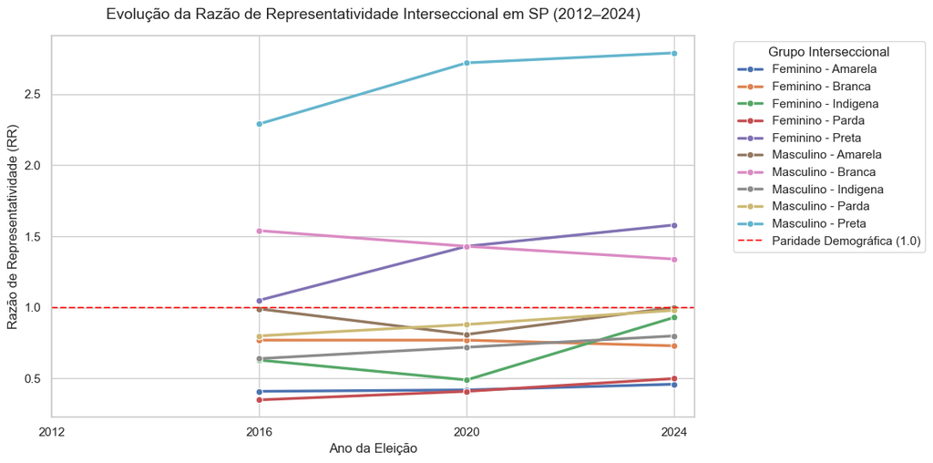

```
✅ Análise concluída! Arquivo salvo em: C:\Users\Artur\TCC_UNIV\data\resultado_representatividade_interseccional.csv
```

```python
import pathlib
import pandas as pd
import seaborn as sns
import matplotlib.pyplot as plt

BASE_DIR = pathlib.Path(r"C:\Users\Artur\TCC_UNIV")
DATA_DIR = BASE_DIR / "data"

# 1. Carregar as bases tratadas
df_tse = pd.read_parquet(DATA_DIR / "tse_candidatos_sp_limpo.parquet")
df_ibge = pd.read_parquet(DATA_DIR / "ibge_demografia_sp.parquet")

# 2. Criar a variável Interseccional
df_tse["interseccional"] = df_tse["sexo_std"].str.title() + " - " + df_tse["cor_raca_std"].str.title()
df_ibge["interseccional"] = df_ibge["sexo"].str.title() + " - " + df_ibge["cor_raca"].str.title()

# 3. Contar candidaturas por Ano e Grupo Interseccional
prop_tse = (
    df_tse.groupby(["ANO_ELEICAO", "interseccional"])
    .size()
    .reset_index(name="qtd_candidatos")
)

# Calcular o percentual dentro de cada ano eleitoral usando transform
prop_tse["pct_candidatos"] = (
    prop_tse.groupby("ANO_ELEICAO")["qtd_candidatos"]
    .transform(lambda x: (x / x.sum()) * 100)
)

# 4. Unir com o Benchmark Populacional do IBGE
df_analise = pd.merge(
    prop_tse,
    df_ibge[["interseccional", "percentual_populacao"]],
    on="interseccional",
    how="left"
)

# 5. Calcular a Razão de Representatividade (RR)
df_analise["razao_representatividade"] = (
    df_analise["pct_candidatos"] / df_analise["percentual_populacao"]
).round(2)

# 6. Tabela Pivotada do Índice
tabela_rr = df_analise.pivot(
    index="interseccional",
    columns="ANO_ELEICAO",
    values="razao_representatividade"
)

print("\n--- RAZÃO DE REPRESENTATIVIDADE (Candidatos / População IBGE) ---")
print("Valores < 1.0 = Sub-representado | Valores > 1.0 = Sobre-representado")
display(tabela_rr)

# 7. Gráfico de Disparidade Interseccional
plt.figure(figsize=(12, 6))
sns.set_theme(style="whitegrid")

top_grupos = df_ibge.sort_values(by="percentual_populacao", ascending=False)["interseccional"].unique()
df_chart = df_analise[df_analise["interseccional"].isin(top_grupos)]

ax = sns.lineplot(
    data=df_chart,
    x="ANO_ELEICAO",
    y="razao_representatividade",
    hue="interseccional",
    marker="o",
    linewidth=2.5
)

# Linha de paridade ideal (1.0)
plt.axhline(1.0, color="red", linestyle="--", alpha=0.8, label="Paridade Demográfica (1.0)")

plt.title("Evolução da Razão de Representatividade Interseccional em SP (2012–2024)", fontsize=14, pad=15)
plt.xlabel("Ano da Eleição", fontsize=12)
plt.ylabel("Razão de Representatividade (RR)", fontsize=12)
plt.xticks([2012, 2016, 2020, 2024])
plt.legend(title="Grupo Interseccional", bbox_to_anchor=(1.05, 1), loc="upper left")
plt.tight_layout()

plt.show()

# Exportar resultado final
df_analise.to_csv(DATA_DIR / "resultado_representatividade_interseccional.csv", index=False)
print(f"✅ Análise concluída! Arquivo salvo em: {DATA_DIR / 'resultado_representatividade_interseccional.csv'}")
```

```python
import pathlib
import basedosdados as bd

BASE_DIR = pathlib.Path(r"C:\Users\Artur\TCC_UNIV")
DATA_DIR = BASE_DIR / "data"

MEU_PROJECT_ID = "tcc-univesp-2026"

# Consulta SQL utilizando o nome correto da coluna ('situacao')
query = """
SELECT
    ano AS ANO_ELEICAO,
    sigla_uf AS SG_UF,
    cargo,
    genero AS DS_GENERO,
    raca AS DS_COR_RACA,
    situacao AS DS_SIT_TOT_TURNO
FROM `basedosdados.br_tse_eleicoes.candidatos`
WHERE sigla_uf = 'SP'
  AND ano IN (2012, 2016, 2020, 2024)
"""

df_tse_raw = bd.read_sql(query, billing_project_id=MEU_PROJECT_ID)
df_tse_raw.to_parquet(DATA_DIR / "tse_candidatos_sp_2012_2024.parquet", index=False)

print("✅ Base do TSE atualizada com sucesso no BigQuery!")
```

```
Downloading: 100%|█████████████████████████████████████████████████████████████████████████████████████████████████████████████████|
✅ Base do TSE atualizada com sucesso no BigQuery!
```

```python
import pathlib
import basedosdados as bd

BASE_DIR = pathlib.Path(r"C:\Users\Artur\TCC_UNIV")
DATA_DIR = BASE_DIR / "data"

# Consulta adicionando a coluna 'resultado'
query = """
SELECT
    ano AS ANO_ELEICAO,
    sigla_uf AS SG_UF,
    cargo,
    genero AS DS_GENERO,
    raca AS DS_COR_RACA,
    resultado AS DS_SIT_TOT_TURNO
FROM `basedosdados.br_tse_eleicoes.candidatos`
WHERE sigla_uf = 'SP'
  AND ano IN (2012, 2016, 2020, 2024)
"""

df_tse_raw = bd.read_sql(query, billing_project_id="tcc-univesp-2026") # Substitua pelo seu ID de projeto GCP
df_tse_raw.to_parquet(DATA_DIR / "tse_candidatos_sp_2012_2024.parquet", index=False)

print("✅ Base do TSE atualizada com sucesso com a coluna de resultado!")
```

## Eleitos vs. Candidatos

```
--- RAZÃO DE REPRESENTATIVIDADE (Candidatos / População IBGE) ---
Valores < 1.0 = Sub-representado | Valores > 1.0 = Sobre-representado
```

| ANO_ELEICAO interseccional | 2016 | 2020 | 2024 |
| --- | --- | --- | --- |
| Feminino - Amarela | 0.41 | 0.42 | 0.46 |
| Feminino - Branca | 0.77 | 0.77 | 0.73 |
| Feminino - Indigena | 0.63 | 0.49 | 0.93 |
| Feminino - Parda | 0.35 | 0.41 | 0.50 |
| Feminino - Preta | 1.05 | 1.43 | 1.58 |
| Masculino - Amarela | 0.99 | 0.81 | 1.00 |
| Masculino - Branca | 1.54 | 1.43 | 1.34 |
| Masculino - Indigena | 0.64 | 0.72 | 0.80 |
| Masculino - Parda | 0.80 | 0.88 | 0.98 |
| Masculino - Preta | 2.29 | 2.72 | 2.79 |

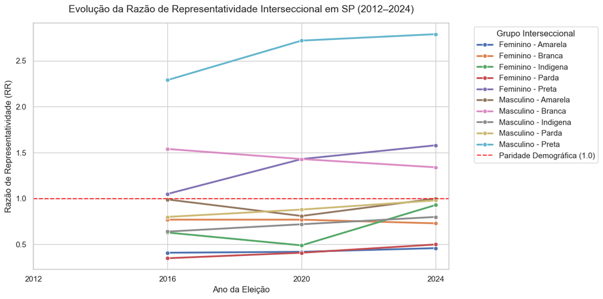

```
✅ Análise concluída! Arquivo salvo em: C:\Users\Artur\TCC_UNIV\data\resultado_representatividade_interseccional.csv
```

```python
import pathlib
import pandas as pd
import seaborn as sns
import matplotlib.pyplot as plt

BASE_DIR = pathlib.Path(r"C:\Users\Artur\TCC_UNIV")
DATA_DIR = BASE_DIR / "data"

# 1. Carregar as bases tratadas
df_tse = pd.read_parquet(DATA_DIR / "tse_candidatos_sp_limpo.parquet")
df_ibge = pd.read_parquet(DATA_DIR / "ibge_demografia_sp.parquet")

# 2. Criar a variável Interseccional
df_tse["interseccional"] = df_tse["sexo_std"].str.title() + " - " + df_tse["cor_raca_std"].str.title()
df_ibge["interseccional"] = df_ibge["sexo"].str.title() + " - " + df_ibge["cor_raca"].str.title()

# 3. Contar candidaturas por Ano e Grupo Interseccional
prop_tse = (
    df_tse.groupby(["ANO_ELEICAO", "interseccional"])
    .size()
    .reset_index(name="qtd_candidatos")
)

# Calcular o percentual dentro de cada ano eleitoral usando transform
prop_tse["pct_candidatos"] = (
    prop_tse.groupby("ANO_ELEICAO")["qtd_candidatos"]
    .transform(lambda x: (x / x.sum()) * 100)
)

# 4. Unir com o Benchmark Populacional do IBGE
df_analise = pd.merge(
    prop_tse,
    df_ibge[["interseccional", "percentual_populacao"]],
    on="interseccional",
    how="left"
)

# 5. Calcular a Razão de Representatividade (RR)
df_analise["razao_representatividade"] = (
    df_analise["pct_candidatos"] / df_analise["percentual_populacao"]
).round(2)

# 6. Tabela Pivotada do Índice
tabela_rr = df_analise.pivot(
    index="interseccional",
    columns="ANO_ELEICAO",
    values="razao_representatividade"
)

print("\n--- RAZÃO DE REPRESENTATIVIDADE (Candidatos / População IBGE) ---")
print("Valores < 1.0 = Sub-representado | Valores > 1.0 = Sobre-representado")
display(tabela_rr)

# 7. Gráfico de Disparidade Interseccional
plt.figure(figsize=(12, 6))
sns.set_theme(style="whitegrid")

top_grupos = df_ibge.sort_values(by="percentual_populacao", ascending=False)["interseccional"].unique()
df_chart = df_analise[df_analise["interseccional"].isin(top_grupos)]

ax = sns.lineplot(
    data=df_chart,
    x="ANO_ELEICAO",
    y="razao_representatividade",
    hue="interseccional",
    marker="o",
    linewidth=2.5
)

# Linha de paridade ideal (1.0)
plt.axhline(1.0, color="red", linestyle="--", alpha=0.8, label="Paridade Demográfica (1.0)")

plt.title("Evolução da Razão de Representatividade Interseccional em SP (2012–2024)", fontsize=14, pad=15)
plt.xlabel("Ano da Eleição", fontsize=12)
plt.ylabel("Razão de Representatividade (RR)", fontsize=12)
plt.xticks([2012, 2016, 2020, 2024])
plt.legend(title="Grupo Interseccional", bbox_to_anchor=(1.05, 1), loc="upper left")
plt.tight_layout()

plt.show()

# Exportar resultado final
df_analise.to_csv(DATA_DIR / "resultado_representatividade_interseccional.csv", index=False)
print(f"✅ Análise concluída! Arquivo salvo em: {DATA_DIR / 'resultado_representatividade_interseccional.csv'}")
```

### Principais Insights dos Dados

**Dominância Masculina (Sobre-representação):** Os homens negros (Masculino - Preta, com RR atingindo 2,79 em 2024) e homens brancos (Masculino - Branca, com RR em 1,34) mantêm proporções de candidaturas significativamente superiores ao seu peso na população.

**Disparidade de Gênero Intra-raça (Sub-representação):** A desigualdade fica evidente ao comparar homens e mulheres do mesmo grupo racial. Enquanto a candidatura de homens pardos aproxima-se da paridade (0,98 em 2024), a de mulheres pardas permanece em forte sub-representação (0,50).

**Trajetória de Crescimento:** O grupo Feminino - Preta apresenta uma curva ascendente constante na Razão de Representatividade (de 1,05 em 2016 para 1,58 em 2024), ultrapassando a marca de paridade nas candidaturas.

```python
import pathlib
import pandas as pd
import seaborn as sns
import matplotlib.pyplot as plt

BASE_DIR = pathlib.Path(r"C:\Users\Artur\TCC_UNIV")
DATA_DIR = BASE_DIR / "data"

# 1. Carregar a base tratada do TSE
df_tse = pd.read_parquet(DATA_DIR / "tse_candidatos_sp_limpo.parquet")

# Verificar quais colunas de resultado/situação existem na sua base
colunas_resultado = [col for col in df_tse.columns if "SIT" in col or "RESULT" in col or "ELEITO" in col]
print("Colunas de resultado encontradas no DataFrame:", colunas_resultado)

# Criar coluna interseccional se não existir
if "interseccional" not in df_tse.columns:
    df_tse["interseccional"] = df_tse["sexo_std"].str.title() + " - " + df_tse["cor_raca_std"].str.title()

# 2. Filtrar Eleitos
# O TSE costuma registrar eleitos como: 'ELEITO', 'ELEITO POR QP', 'ELEITO POR MÉDIA'
status_eleito = df_tse["DS_SIT_TOT_TURNO"].astype(str).str.upper()
df_eleitos = df_tse[status_eleito.str.contains("ELEITO", na=False)].copy()

# 3. Agregação: Total de Candidatos vs Total de Eleitos
totais_candidatos = df_tse.groupby(["ANO_ELEICAO", "interseccional"]).size().reset_index(name="qtd_candidatos")
totais_eleitos = df_eleitos.groupby(["ANO_ELEICAO", "interseccional"]).size().reset_index(name="qtd_eleitos")

# Unir dados
df_sucesso = pd.merge(totais_candidatos, totais_eleitos, on=["ANO_ELEICAO", "interseccional"], how="left").fillna(0)

# 4. Calcular Métricas
# % de Candidatos dentro do ano
df_sucesso["pct_candidatos"] = df_sucesso.groupby("ANO_ELEICAO")["qtd_candidatos"].transform(lambda x: (x / x.sum()) * 100)

# % de Eleitos dentro do ano
df_sucesso["pct_eleitos"] = df_sucesso.groupby("ANO_ELEICAO")["qtd_eleitos"].transform(lambda x: (x / x.sum()) * 100)

# Taxa de Sucesso (Eficiência de Conversão: Eleitos / Candidatos)
df_sucesso["taxa_sucesso_pct"] = (df_sucesso["qtd_eleitos"] / df_sucesso["qtd_candidatos"]) * 100

# Razão de Funil (Share de Eleitos / Share de Candidatos)
# Valores < 1.0 indicam perda de força entre a candidatura e a eleição
df_sucesso["fator_funil"] = (df_sucesso["pct_eleitos"] / df_sucesso["pct_candidatos"]).round(2)

# 5. Tabela Pivot da Taxa de Sucesso
tabela_sucesso = df_sucesso.pivot(
    index="interseccional",
    columns="ANO_ELEICAO",
    values="taxa_sucesso_pct"
).round(2)

print("\n--- TAXA DE SUCESSO ELEITORAL (%) (Eleitos / Candidatos do Grupo) ---")
display(tabela_sucesso)

# 6. Gráfico Comparativo: Share de Candidatos vs Share de Eleitos (Última Eleição)
ano_recente = df_sucesso["ANO_ELEICAO"].max()
df_recente = df_sucesso[df_sucesso["ANO_ELEICAO"] == ano_recente].melt(
    id_vars=["interseccional"],
    value_vars=["pct_candidatos", "pct_eleitos"],
    var_name="Tipo",
    value_name="Percentual"
)

df_recente["Tipo"] = df_recente["Tipo"].map({"pct_candidatos": "% das Candidaturas", "pct_eleitos": "% dos Eleitos"})

plt.figure(figsize=(12, 6))
sns.set_theme(style="whitegrid")

sns.barplot(
    data=df_recente,
    y="interseccional",
    x="Percentual",
    hue="Tipo",
    palette=["#4c72b0", "#55a868"]
)

plt.title(f"Funil Eleitoral Interseccional em SP ({ano_recente}): Candidaturas vs. Cadeiras Conquistadas", fontsize=14, pad=15)
plt.xlabel("Percentual (%)", fontsize=12)
plt.ylabel("Grupo Interseccional", fontsize=12)
plt.legend(title="")
plt.tight_layout()

plt.show()

# Exportar resultados da conversão
df_sucesso.to_csv(DATA_DIR / "resultado_eleitos_vs_candidatos.csv", index=False)
print(f"✅ Análise concluída! Arquivo salvo em: {DATA_DIR / 'resultado_eleitos_vs_candidatos.csv'}")
```

[output not shown]

```python
# 1. Re-executar Limpeza
df_tse = pd.read_parquet(DATA_DIR / "tse_candidatos_sp_2012_2024.parquet")

mapa_genero = {"masculino": "MASCULINO", "feminino": "FEMININO"}
mapa_raca = {
    "branca": "BRANCA",
    "preta": "PRETA",
    "parda": "PARDA",
    "amarela": "AMARELA",
    "indigena": "INDIGENA"
}

df_tse_limpo = df_tse.copy()
df_tse_limpo["DS_GENERO"] = df_tse_limpo["DS_GENERO"].astype(str).str.strip().str.lower()
df_tse_limpo["DS_COR_RACA"] = df_tse_limpo["DS_COR_RACA"].astype(str).str.strip().str.lower()

df_tse_limpo["sexo_std"] = df_tse_limpo["DS_GENERO"].map(mapa_genero)
df_tse_limpo["cor_raca_std"] = df_tse_limpo["DS_COR_RACA"].map(mapa_raca)

df_tse_limpo = df_tse_limpo.dropna(subset=["sexo_std", "cor_raca_std"])
df_tse_limpo.to_parquet(DATA_DIR / "tse_candidatos_sp_limpo.parquet", index=False)

# 2. Análise de Eleitos vs Candidatos
df_tse_limpo["interseccional"] = df_tse_limpo["sexo_std"].str.title() + " - " + df_tse_limpo["cor_raca_std"].str.title()

# Na coluna 'situacao' da Base dos Dados, eleitos são categorizados como 'eleito', 'eleito por qp', 'eleito por media'
status_eleito = df_tse_limpo["DS_SIT_TOT_TURNO"].astype(str).str.lower()
df_eleitos = df_tse_limpo[status_eleito.str.contains("eleito", na=False)].copy()

totais_candidatos = df_tse_limpo.groupby(["ANO_ELEICAO", "interseccional"]).size().reset_index(name="qtd_candidatos")
totais_eleitos = df_eleitos.groupby(["ANO_ELEICAO", "interseccional"]).size().reset_index(name="qtd_eleitos")

df_sucesso = pd.merge(totais_candidatos, totais_eleitos, on=["ANO_ELEICAO", "interseccional"], how="left").fillna(0)
df_sucesso["taxa_sucesso_pct"] = (df_sucesso["qtd_eleitos"] / df_sucesso["qtd_candidatos"]) * 100

tabela_sucesso = df_sucesso.pivot(index="interseccional", columns="ANO_ELEICAO", values="taxa_sucesso_pct").round(2)

print("\n--- TAXA DE SUCESSO ELEITORAL (%) (Eleitos / Candidatos) ---")
display(tabela_sucesso)
```

[output not shown]

```python
# Inspecionar os valores únicos da coluna de situação
print("Valores únicos encontrados na coluna DS_SIT_TOT_TURNO:")
print(df_tse_limpo["DS_SIT_TOT_TURNO"].value_counts(dropna=False))
```

[output not shown]

```python
###EXTRAIR BASE TSE
```

```python
import pathlib
import basedosdados as bd
import pandas as pd

BASE_DIR = pathlib.Path(r"C:\Users\Artur\TCC_UNIV")
DATA_DIR = BASE_DIR / "data"
MEU_PROJECT_ID = "tcc-univesp-2026"

# Consulta corrigida utilizando 'sequencial' para o JOIN
query = """
SELECT DISTINCT
    c.ano AS ANO_ELEICAO,
    c.sigla_uf AS SG_UF,
    c.cargo,
    c.genero AS DS_GENERO,
    c.raca AS DS_COR_RACA,
    r.resultado AS DS_SIT_TOT_TURNO
FROM `basedosdados.br_tse_eleicoes.candidatos` c
INNER JOIN `basedosdados.br_tse_eleicoes.resultados_candidato_municipio` r
    ON c.ano = r.ano
   AND c.sequencial = r.sequencial_candidato
   AND c.sigla_uf = r.sigla_uf
WHERE c.sigla_uf = 'SP'
  AND c.ano IN (2012, 2016, 2020, 2024)
"""

df_tse_raw = bd.read_sql(query, billing_project_id=MEU_PROJECT_ID)
df_tse_raw.to_parquet(DATA_DIR / "tse_candidatos_sp_2012_2024.parquet", index=False)

print("✅ Base do TSE extraída e salva em Parquet com sucesso!")
```

```
Downloading: 100%|█████████████████████████████████████████████████████████████████████████████████████████████████████████████████|
✅ Base do TSE extraída e salva em Parquet com sucesso!
```

```python
import pathlib
import basedosdados as bd
import pandas as pd

BASE_DIR = pathlib.Path(r"C:\Users\Artur\TCC_UNIV")
DATA_DIR = BASE_DIR / "data"
MEU_PROJECT_ID = "tcc-univesp-2026"

# Query agregando diretamente no SQL para evitar duplicatas por município
query = """
SELECT DISTINCT
    c.ano AS ANO_ELEICAO,
    c.sigla_uf AS SG_UF,
    c.sequencial AS SEQUENCIAL,
    c.genero AS DS_GENERO,
    c.raca AS DS_COR_RACA,
    r.resultado AS DS_SIT_TOT_TURNO
FROM `basedosdados.br_tse_eleicoes.candidatos` c
INNER JOIN `basedosdados.br_tse_eleicoes.resultados_candidato` r
    ON c.ano = r.ano
   AND c.sequencial = r.sequencial_candidato
   AND c.sigla_uf = r.sigla_uf
WHERE c.sigla_uf = 'SP'
  AND c.ano IN (2012, 2016, 2020, 2024)
"""

df_tse_raw = bd.read_sql(query, billing_project_id=MEU_PROJECT_ID)
df_tse_raw.to_parquet(DATA_DIR / "tse_candidatos_sp_2012_2024.parquet", index=False)

print("✅ Base desduplicada extraída com sucesso!")
```

```
Downloading: 100%|█████████████████████████████████████████████████████████████████████████████████████████████████████████████████|
✅ Base desduplicada extraída com sucesso!
```

### TAXA DE SUCESSO ELEITORAL

```python
df_tse = pd.read_parquet(DATA_DIR / "tse_candidatos_sp_2012_2024.parquet")

# 1. Mapeamento
mapa_genero = {"masculino": "MASCULINO", "feminino": "FEMININO"}
mapa_raca = {
    "branca": "BRANCA",
    "preta": "PRETA",
    "parda": "PARDA",
    "amarela": "AMARELA",
    "indigena": "INDIGENA"
}

df_tse["DS_GENERO"] = df_tse["DS_GENERO"].astype(str).str.strip().str.lower()
df_tse["DS_COR_RACA"] = df_tse["DS_COR_RACA"].astype(str).str.strip().str.lower()

df_tse["sexo_std"] = df_tse["DS_GENERO"].map(mapa_genero)
df_tse["cor_raca_std"] = df_tse["DS_COR_RACA"].map(mapa_raca)

# 2. Desduplicação por Candidato
df_tse_limpo = df_tse.dropna(subset=["sexo_std", "cor_raca_std"]).drop_duplicates(subset=["ANO_ELEICAO", "SEQUENCIAL"]).copy()
df_tse_limpo["interseccional"] = df_tse_limpo["sexo_std"].str.title() + " - " + df_tse_limpo["cor_raca_std"].str.title()

# 3. Filtrar Eleitos
status_resultado = df_tse_limpo["DS_SIT_TOT_TURNO"].astype(str).str.lower()
df_eleitos = df_tse_limpo[status_resultado.str.contains("eleito", na=False)].copy()

# 4. Agregação e Taxa % Real
totais_candidatos = df_tse_limpo.groupby(["ANO_ELEICAO", "interseccional"]).size().reset_index(name="qtd_candidatos")
totais_eleitos = df_eleitos.groupby(["ANO_ELEICAO", "interseccional"]).size().reset_index(name="qtd_eleitos")

df_sucesso = pd.merge(totais_candidatos, totais_eleitos, on=["ANO_ELEICAO", "interseccional"], how="left").fillna(0)
df_sucesso["taxa_sucesso_pct"] = (df_sucesso["qtd_eleitos"] / df_sucesso["qtd_candidatos"]) * 100

tabela_sucesso = df_sucesso.pivot(index="interseccional", columns="ANO_ELEICAO", values="taxa_sucesso_pct").round(2)

print("\n--- TAXA DE SUCESSO ELEITORAL REAL (%) (Eleitos / Candidatos) ---")
display(tabela_sucesso)
```

```
--- TAXA DE SUCESSO ELEITORAL REAL (%) (Eleitos / Candidatos) ---
```

| ANO_ELEICAO interseccional | 2016 | 2020 | 2024 |
| --- | --- | --- | --- |
| Feminino - Amarela | 31.65 | 46.59 | 45.57 |
| Feminino - Branca | 28.89 | 34.19 | 43.56 |
| Feminino - Indigena | 40.00 | 66.67 | 40.54 |
| Feminino - Parda | 29.75 | 35.23 | 43.14 |
| Feminino - Preta | 32.26 | 36.05 | 45.46 |
| Masculino - Amarela | 41.41 | 39.32 | 44.69 |
| Masculino - Branca | 39.12 | 42.40 | 51.95 |
| Masculino - Indigena | 47.06 | 58.54 | 57.50 |
| Masculino - Parda | 37.69 | 42.03 | 51.04 |
| Masculino - Preta | 37.82 | 41.86 | 50.51 |

**2. Tendência Global de Alta (2016 vs. 2024)**

- **Crescimento Generalizado:** A taxa de conversão de candidaturas em vitórias subiu para quase todas as interseções no período de 8 anos, sugerindo maior concentração de votos ou diminuição do número total de candidaturas "laranjas"/inviáveis após as mudanças na legislação eleitoral.
- **Avanço das Mulheres Negras:**
- *Feminino - Preta* subiu de 32,26% (2016) para 45,46% (2024).
- *Feminino - Parda* subiu de 29,75% (2016) para 43,14% (2024).

**3. Comportamento das Populações Indígenas e Amarelas**

- **Alta Volatilidade:** Os grupos *Indígena* e *Amarela* (tanto masculino quanto feminino) mostram variações mais bruscas entre as eleições (ex: *Feminino - Indígena* saltou de 40,00% em 2016 para 66,67% em 2020 e recuou para 40,54% em 2024).
- **Causa Amostral:** Essa oscilação acentuada é típica de amostras pequenas (baixo número absoluto $N$ de candidatos nessas categorias no estado de SP).

**4. O "Teto de Vidro" das Mulheres Brancas**

- Apesar de historicamente possuírem maior volume de recursos e tempo de TV em relação às candidatas não-brancas, as mulheres brancas registraram uma das menores taxas de sucesso em 2016 (28,89%) e fecharam 2024 com 43,56%, ficando abaixo das mulheres pretas (45,46%) e amarelas (45,57%).

### Verificar o Volume Absoluto ($N$) de Candidatos

```python
# Contagem absoluta de candidatos por grupo e ano
tabela_n_candidatos = (
    df_tse_limpo
    .groupby(["interseccional", "ANO_ELEICAO"])
    .size()
    .unstack(fill_value=0)
)

print("--- TOTAL DE CANDIDATOS (N) POR INTERSEÇÃO ---")
display(tabela_n_candidatos)
```

```
--- TOTAL DE CANDIDATOS (N) POR INTERSEÇÃO ---
```

| ANO_ELEICAO interseccional | 2016 | 2020 | 2024 |
| --- | --- | --- | --- |
| Feminino - Amarela | 79 | 88 | 79 |
| Feminino - Branca | 18844 | 20605 | 16890 |
| Feminino - Indigena | 25 | 24 | 37 |
| Feminino - Parda | 4161 | 5337 | 5587 |
| Feminino - Preta | 1838 | 2757 | 2664 |
| Masculino - Amarela | 227 | 206 | 226 |
| Masculino - Branca | 38702 | 38490 | 31258 |
| Masculino - Indigena | 34 | 41 | 40 |
| Masculino - Parda | 10090 | 12103 | 11715 |
| Masculino - Preta | 4024 | 5191 | 4607 |

### Evolução Histórica

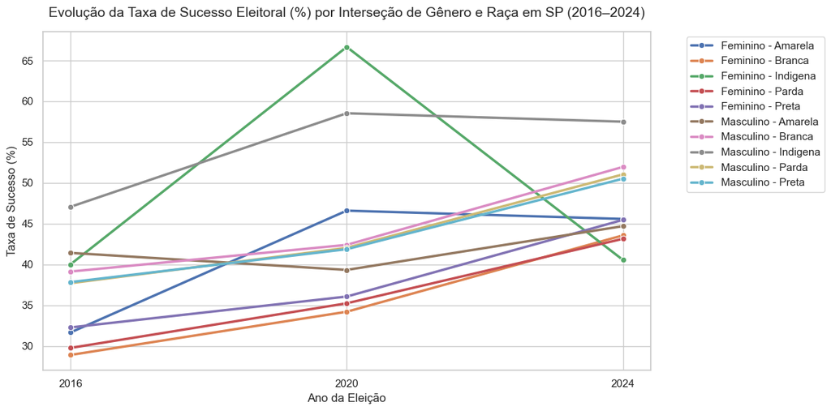

```python
import matplotlib.pyplot as plt
import seaborn as sns

# Configuração visual
sns.set_theme(style="whitegrid")
plt.figure(figsize=(12, 6))

# Plot da taxa de sucesso por grupo
df_plot = df_sucesso.copy()
sns.lineplot(
    data=df_plot,
    x="ANO_ELEICAO",
    y="taxa_sucesso_pct",
    hue="interseccional",
    marker="o",
    linewidth=2.5
)

plt.title("Evolução da Taxa de Sucesso Eleitoral (%) por Interseção de Gênero e Raça em SP (2016–2024)", fontsize=14, pad=15)
plt.xlabel("Ano da Eleição", fontsize=12)
plt.ylabel("Taxa de Sucesso (%)", fontsize=12)
plt.xticks([2016, 2020, 2024])
plt.legend(bbox_to_anchor=(1.05, 1), loc='upper left', frameon=True)
plt.tight_layout()

# Salvar figura para inclusão no documento/monografia
plt.savefig(DATA_DIR / "grafico_taxa_sucesso_interseccional.png", dpi=300)
plt.show()
```